# Liver Cancer Prediction: Model Training and Evaluation

This script focuses on the training, evaluation, and optimization of Machine Learning models for predicting liver cancer.

The following steps are performed:

- **Loading and preparing the dataset,** ensuring compatibility between training and test sets.
- **Comparing different Machine Learning algorithms,** including Logistic Regression, Decision Trees, Random Forest, Support Vector Machines (SVM), and Gradient Boosting models.
- **Hyperparameter tuning** to optimize model performance using GridSearchCV and RandomizedSearchCV.
- **Evaluation of models based on key metrics such as Accuracy, Recall, Precision, F1-Score, and ROC-AUC,** with a focus on recall due to the critical nature of detecting liver cancer cases.
- **Final model selection,** identifying the best-performing model for accurate liver cancer prediction.

This structured approach ensures that the most effective and reliable model is selected for detecting liver cancer, improving early diagnosis and potential treatment planning.

Author: Juan Armario  
Date: 2024

# Importing libraries

```python
import pandas as pd
import numpy as np
import shap

## Others
import warnings
import sys
from collections import Counter

## Plot
import seaborn as sns
import matplotlib
import matplotlib.pyplot as plt

# Suppress warnings for cleaner output
warnings.filterwarnings('ignore')

# Custom functions
sys.path.append("../0. Scripts")
import data_analysing_functions as daf
import model_metrics_functions as mmf

## Selection Models
from sklearn.model_selection import train_test_split, GridSearchCV, StratifiedKFold, RandomizedSearchCV, cross_val_score, cross_validate, learning_curve

## Model
from sklearn.linear_model import LogisticRegression
from sklearn.neighbors import KNeighborsRegressor
from sklearn.ensemble import RandomForestRegressor, RandomForestClassifier, AdaBoostClassifier, GradientBoostingClassifier, ExtraTreesClassifier
from sklearn.svm import SVR, LinearSVC
from sklearn.tree import DecisionTreeClassifier
import xgboost as xgb
from xgboost import XGBRegressor, XGBClassifier

## Metrics
from sklearn.metrics import mean_squared_error, r2_score, confusion_matrix, accuracy_score
from sklearn.metrics import classification_report, balanced_accuracy_score, make_scorer
from sklearn.metrics import precision_score, recall_score, f1_score, matthews_corrcoef
from sklearn.metrics import roc_curve, auc

## Dataset balancing
from imblearn.over_sampling import SMOTE
```

# Loading Data

```python
# Imputed dataset
balanced_df = pd.read_csv('../0. Data/5. Balanced/balanced_train_df.csv')
test_no_target_df = pd.read_csv('../0. Data/4. Transformed/transformed_removing_below_mean_test_df.csv')
test_full_df = pd.read_csv('../0. Data/2. Training and Test/data_test_full_df.csv')

pd.set_option('display.max_columns', None)
```

```python
# Removing target variable
balanced_copy_df = balanced_df.copy()
balanced_no_target_df = balanced_copy_df.drop(columns=['liver_cancer'])
```

```python
missing_train_cols = set(test_no_target_df.columns) - set(balanced_df.columns)
missing_test_cols = set(balanced_df.columns) - set(test_no_target_df.columns)

print(f"Missing in train: {missing_train_cols}")
print(f"Missing in test: {missing_test_cols}")
```

```
Missing in train: set()
Missing in test: {'liver_cancer'}
```

```python
target = balanced_df.liver_cancer
target.info()
```

```
<class 'pandas.core.series.Series'>
RangeIndex: 238626 entries, 0 to 238625
Series name: liver_cancer
Non-Null Count   Dtype
--------------   -----
238626 non-null  int64
dtypes: int64(1)
memory usage: 1.8 MB
```

```python
# Splitting features (X) and target variable (y) for test and training
X_train = balanced_no_target_df
y_train = target
X_test = test_no_target_df
y_test = test_full_df.liver_cancer
```

```python
missing_train_cols = set(X_test.columns) - set(X_train.columns)
missing_test_cols = set(X_train.columns) - set(X_test.columns)

print(f"Missing in train: {missing_train_cols}")
print(f"Missing in test: {missing_test_cols}")
```

```
Missing in train: set()
Missing in test: set()
```

# Model creation

In this section, we focus on building and training Machine Learning models for liver cancer prediction. The goal is to evaluate multiple algorithms to determine which one provides the best predictive performance.

The process involves:

- Defining a **set of candidate models,** including **Logistic Regression, Decision Trees, Random Forest, Support Vector Machines (SVM), AdaBoost, and XGBoost.**
- Establishing **evaluation metrics** to compare models based on their ability to accurately classify liver cancer cases.
- Implementing **cross-validation** to ensure robust and unbiased model assessment.

By systematically comparing different approaches, we aim to identify the most effective model for reliable liver cancer detection.

## Algorithms comparison

In this section, we conduct a comprehensive evaluation of multiple Machine Learning algorithms to identify the most suitable model for liver cancer prediction. By testing different classifiers, we aim to determine which algorithm offers the best balance between accuracy, recall, and robustness.

The comparison includes:

- Training and validating **Logistic Regression, Decision Trees, Random Forest, Linear SVC, AdaBoost, and XGBoost models.**
- Using **cross-validation** to assess model consistency across different data splits.
- Measuring performance with key metrics such as **accuracy, recall, precision, F1-score, and Matthews correlation coefficient (MCC).**

This analysis provides critical insights into which models are best suited for the dataset, allowing for an informed decision on the final model selection.

```python
# Classifiers definition
classifiers = {
    'Logistic Regression': LogisticRegression(random_state=42),
    'Decision Tree Classifier': DecisionTreeClassifier(random_state=42),
    'Random Forest Classifier': RandomForestClassifier(random_state=42),
    'Linear SVC': LinearSVC(random_state=42, tol=1e-3),
    'AdaBoost Classifier': AdaBoostClassifier(random_state=42),
    'XGBoost Classifier': XGBClassifier(use_label_encoder=False, eval_metric='logloss', random_state=42)
}

# Metrics definition
metrics = {
    "accuracy": make_scorer(accuracy_score),
    "balanced_accuracy": make_scorer(balanced_accuracy_score),
    "precision": make_scorer(precision_score, pos_label=1),
    "recall": make_scorer(recall_score, pos_label=1),
    "f1": make_scorer(f1_score, pos_label=1),
    "mcc": make_scorer(matthews_corrcoef)
}
```

```python
results, names = mmf.rskf_comparison_with_metrics(classifiers, X_train, y_train, metrics)
```

```
Logistic Regression
Accuracy Mean: 0.67100 (+/- 0.00704)
Balanced_accuracy Mean: 0.67100 (+/- 0.00704)
Precision Mean: 0.65093 (+/- 0.00706)
Recall Mean: 0.73751 (+/- 0.00577)
F1 Mean: 0.69152 (+/- 0.00588)
Mcc Mean: 0.34506 (+/- 0.01393)
-------------------------
Decision Tree Classifier
Accuracy Mean: 0.99146 (+/- 0.00196)
Balanced_accuracy Mean: 0.99146 (+/- 0.00196)
Precision Mean: 0.99363 (+/- 0.00206)
Recall Mean: 0.98926 (+/- 0.00588)
F1 Mean: 0.99144 (+/- 0.00200)
Mcc Mean: 0.98294 (+/- 0.00387)
-------------------------
Random Forest Classifier
Accuracy Mean: 0.99214 (+/- 0.00265)
Balanced_accuracy Mean: 0.99214 (+/- 0.00265)
Precision Mean: 0.99489 (+/- 0.00089)
Recall Mean: 0.98937 (+/- 0.00620)
F1 Mean: 0.99212 (+/- 0.00269)
Mcc Mean: 0.98431 (+/- 0.00524)
-------------------------
Linear SVC
Accuracy Mean: 0.61683 (+/- 0.05998)
Balanced_accuracy Mean: 0.61683 (+/- 0.05999)
Precision Mean: 0.65966 (+/- 0.09572)
Recall Mean: 0.54144 (+/- 0.45268)
F1 Mean: 0.55755 (+/- 0.26942)
Mcc Mean: 0.25589 (+/- 0.08891)
-------------------------
AdaBoost Classifier
Accuracy Mean: 0.94133 (+/- 0.00604)
Balanced_accuracy Mean: 0.94133 (+/- 0.00604)
Precision Mean: 0.98803 (+/- 0.00172)
Recall Mean: 0.89347 (+/- 0.01104)
F1 Mean: 0.93837 (+/- 0.00665)
Mcc Mean: 0.88673 (+/- 0.01130)
-------------------------
XGBoost Classifier
Accuracy Mean: 0.99118 (+/- 0.00233)
Balanced_accuracy Mean: 0.99118 (+/- 0.00233)
Precision Mean: 0.99656 (+/- 0.00205)
Recall Mean: 0.98577 (+/- 0.00624)
F1 Mean: 0.99113 (+/- 0.00238)
Mcc Mean: 0.98243 (+/- 0.00457)
-------------------------
```

## Hyperparameter tuning

Once the best-performing algorithms have been identified, the next step is optimizing their hyperparameters to enhance predictive performance. Hyperparameter tuning is a crucial process in **fine-tuning model behavior,** preventing underfitting or overfitting, and improving generalization.

In this section, we:

- Utilize **RandomizedSearchCV** to efficiently explore a range of hyperparameter values for **Random Forest and XGBoost** models.
- Optimize key parameters such as **number of estimators, learning rate, maximum depth, and class balancing techniques.**
- Evaluate models using **recall as the primary scoring metric,** ensuring better detection of liver cancer cases.

By refining these hyperparameters, we ensure that the selected models perform optimally, making them more reliable for real-world application.

```python
# Random Forest parameters definition
rf_randomized_param_grid = {
    'n_estimators': [100, 200, 300],
    'class_weight': ['balanced', None],
    'criterion': ['gini', 'entropy'],
    'max_features': ['auto', 'sqrt', 'log2'],
    'max_depth': [16,20,24]
}

# Random Forest model definition
rf_randomized_model = RandomForestClassifier(random_state=42)

# RandomizedSearchCV configuration for Random Forest
rf_randomized_search = RandomizedSearchCV(estimator=rf_randomized_model, param_distributions=rf_randomized_param_grid, scoring='recall', n_iter=10, cv=5, verbose=1, random_state=42,)

# Fit the model
rf_randomized_search.fit(X_train, y_train)

# Results
print("Best parameters for Random Forest: ", rf_randomized_search.best_params_)
print("Best score for Random Forest: ", rf_randomized_search.best_score_)
```

```
Fitting 5 folds for each of 10 candidates, totalling 50 fits
Best parameters for Random Forest:  {'n_estimators': 300, 'max_features': 'sqrt', 'max_depth': 20, 'criterion': 'entropy', 'class_weight': None}
Best score for Random Forest:  0.989489849499307
```

```python
# XGBoost parameters definition
xgb_randomized_param_grid = {
    'n_estimators': [100, 200, 300],
    'max_depth': [3, 6, 10],
    'learning_rate': [0.01, 0.1, 0.3],
    'scale_pos_weight': [1, 10]
}

# XGBoost model definition
xgb_randomized_model = xgb.XGBClassifier(random_state=42, objective='binary:logistic', eval_metric='logloss')

# RandomizedSearchCV configuration for XGBoost
xgb_randomized_search = RandomizedSearchCV(estimator=xgb_randomized_model, param_distributions=xgb_randomized_param_grid, cv=5, scoring='recall', verbose=1)

# Model fit
xgb_randomized_search.fit(X_train, y_train)

# Results
print("Best parameters for XGBoost: ", xgb_randomized_search.best_params_)
print("Best score for XGBoost: ", xgb_randomized_search.best_score_)
```

```
Fitting 5 folds for each of 10 candidates, totalling 50 fits
Best parameters for XGBoost:  {'scale_pos_weight': 10, 'n_estimators': 200, 'max_depth': 6, 'learning_rate': 0.01}
Best score for XGBoost:  0.9987344262854526
```

```python
'''
rf_param_grid = {
    'n_estimators': [100, 200, 300],
    'class_weight': ['balanced', None],
    'criterion': ['gini', 'entropy'],
    'max_features': ['auto', 'sqrt', 'log2'],
    'max_depth': [16,20,24]
}

rf_model = RandomForestClassifier(random_state=42)
rf_grid_search = GridSearchCV(estimator=rf_model, param_grid=rf_param_grid, cv=5, scoring='recall', verbose=1)
rf_grid_search.fit(X_train, y_train)

print("Best parameters for Random Forest: ", rf_grid_search.best_params_)
print("Best score for Random Forest: ", rf_grid_search.best_score_)'''
```

[output not shown]

```python
'''
xgb_param_grid = {
    'n_estimators': [100, 200, 300],
    'max_depth': [3, 6, 10],
    'learning_rate': [0.01, 0.1, 0.3],
    'scale_pos_weight': [1, 10]
}

xgb_model = xgb.XGBClassifier(random_state=42, objective='binary:logistic', eval_metric='logloss')
xgb_grid_search = GridSearchCV(estimator=xgb_model, param_grid=xgb_param_grid, cv=5, scoring='recall', verbose=1)
xgb_grid_search.fit(X_train, y_train)

print("Best parameters for XGBoost: ", xgb_grid_search.best_params_)
print("Best score for XGBoost: ", xgb_grid_search.best_score_)'''
```

[output not shown]

# Training and Evaluation with best parameters

After identifying the optimal hyperparameters for the best-performing models, the next step is training and evaluating them to assess their performance on the dataset. This phase ensures that the models not only fit well to the training data but also generalize effectively to unseen cases.

In this section, we:

- Train **Random Forest and XGBoost** using the best hyperparameters obtained from the tuning process.
- Evaluate performance on both the **training and test sets,** analyzing **recall, accuracy, and cross-validation scores.**
- Detect potential **overfitting** by comparing training and test performance.
- Use **learning curves, confusion matrices, and ROC curves** to gain deeper insights into the models’ strengths and weaknesses.

This step is crucial for determining the most reliable and robust model for predicting liver cancer, ensuring that it performs well in practical applications.

```python
# RandomForest model evaluation with the best parameters
rf_model = rf_randomized_search.best_estimator_
rf_model.fit(X_train, y_train)

# Predict and get recall
train_recall_rf = recall_score(y_train, rf_model.predict(X_train), zero_division=0)
test_recall_rf = recall_score(y_test, rf_model.predict(X_test), zero_division=0)

# Evaluation with cross-validation
cv_scores_rf = cross_val_score(rf_model, X_train, y_train, cv=5, scoring='recall')
```

```python
# XGBoost model evaluation with the best parameters
xgb_model = xgb_randomized_search.best_estimator_
xgb_model.fit(X_train, y_train)

# Predict and get recall
train_recall_xgb = recall_score(y_train, xgb_model.predict(X_train), zero_division=0)
test_recall_xgb = recall_score(y_test, xgb_model.predict(X_test), zero_division=0)

# Evaluation with cross-validation
cv_scores_xgb = cross_val_score(xgb_model, X_train, y_train, cv=5, scoring='recall')
```

```
RandomForest Train Recall: 0.9905
RandomForest Test Recall: 0.0256
RandomForest Cross-Validation Recall: 0.9895 (+/- 0.0031)
XGBoost Train Recall: 0.9989
XGBoost Test Recall: 0.4615
XGBoost Cross-Validation Recall: 0.9987 (+/- 0.0010)
```

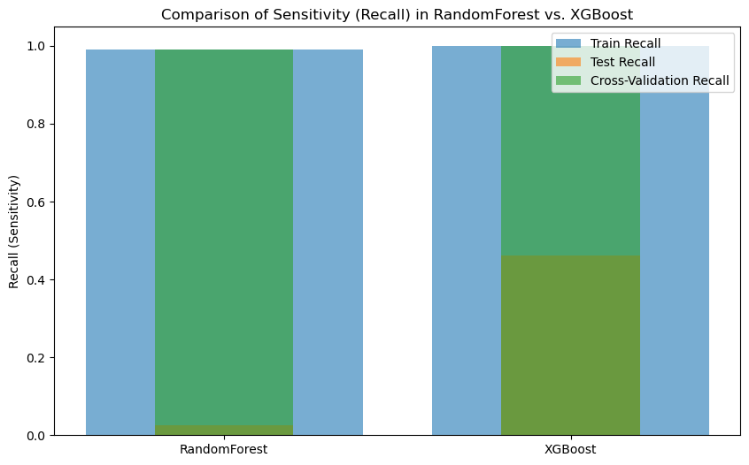

```python
# Showing results
print(f"RandomForest Train Recall: {train_recall_rf:.4f}")
print(f"RandomForest Test Recall: {test_recall_rf:.4f}")
print(f"RandomForest Cross-Validation Recall: {cv_scores_rf.mean():.4f} (+/- {cv_scores_rf.std():.4f})")

print(f"XGBoost Train Recall: {train_recall_xgb:.4f}")
print(f"XGBoost Test Recall: {test_recall_xgb:.4f}")
print(f"XGBoost Cross-Validation Recall: {cv_scores_xgb.mean():.4f} (+/- {cv_scores_xgb.std():.4f})")

# Performance plotting to evaluate the overfitting
models = ['RandomForest', 'XGBoost']
train_recalls = [train_recall_rf, train_recall_xgb]
test_recalls = [test_recall_rf, test_recall_xgb]
cv_recalls = [cv_scores_rf.mean(), cv_scores_xgb.mean()]

# Plot
fig, ax = plt.subplots(figsize=(10, 6))
ax.bar(models, train_recalls, alpha=0.6, label='Train Recall')
ax.bar(models, test_recalls, alpha=0.6, label='Test Recall', width=0.4)
ax.bar(models, cv_recalls, alpha=0.6, label='Cross-Validation Recall', width=0.4)
ax.set_ylabel('Recall (Sensitivity)')
ax.set_title('Comparison of Sensitivity (Recall) in RandomForest vs. XGBoost')
ax.legend()
plt.show()
```

```
Train scores (mean): [0.54285714 0.46397478 0.97248698 0.98759158 0.99052484]
```

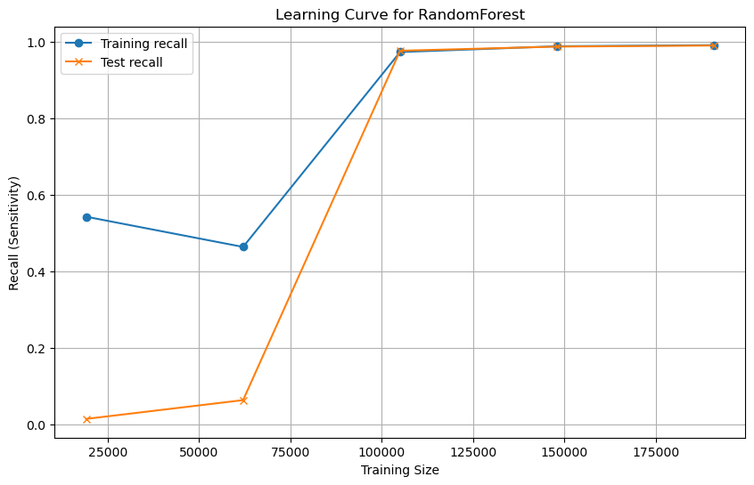

```python
# Create a custom scorer for recall with zero_division
recall_scorer = make_scorer(recall_score, zero_division=0)

# Calculate learning curves for RandomForest
train_sizes, train_scores, test_scores = learning_curve(
    rf_model, X_train, y_train, cv=5, scoring=recall_scorer, n_jobs=-1)

# NaN or null verification
print(f"Train scores (mean): {train_scores.mean(axis=1)}")

train_mean = train_scores.mean(axis=1)
test_mean = test_scores.mean(axis=1)

# Plot
plt.figure(figsize=(10, 6))
plt.plot(train_sizes, train_mean, label='Training recall', marker='o')
plt.plot(train_sizes, test_mean, label='Test recall', marker='x')
plt.xlabel('Training Size')
plt.ylabel('Recall (Sensitivity)')
plt.title('Learning Curve for RandomForest')
plt.legend()
plt.grid(True)
plt.show()
```

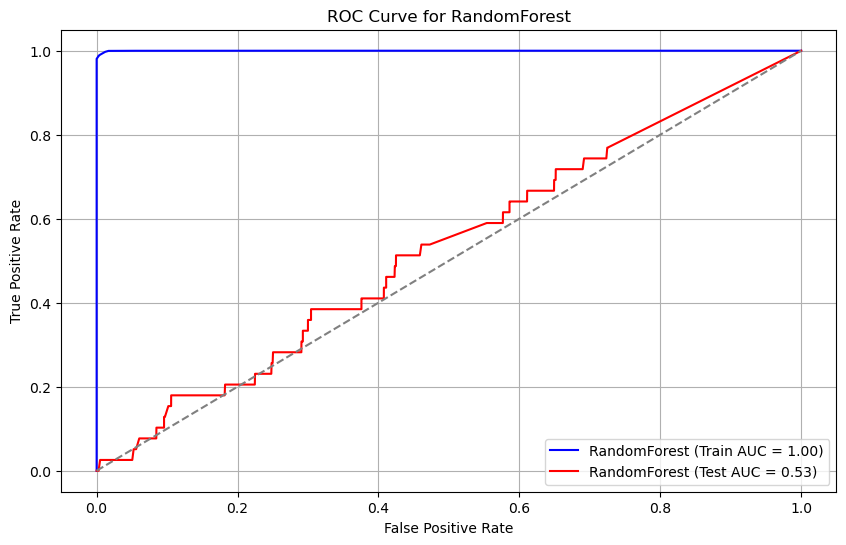

```python
# Get probability predictions
y_train_prob_rf = rf_model.predict_proba(X_train)[:, 1]
y_test_prob_rf = rf_model.predict_proba(X_test)[:, 1]

# ROC curves
fpr_train_rf, tpr_train_rf, _ = roc_curve(y_train, y_train_prob_rf)
fpr_test_rf, tpr_test_rf, _ = roc_curve(y_test, y_test_prob_rf)

# AUC
roc_auc_train_rf = auc(fpr_train_rf, tpr_train_rf)
roc_auc_test_rf = auc(fpr_test_rf, tpr_test_rf)

# Plot
plt.figure(figsize=(10, 6))
plt.plot(fpr_train_rf, tpr_train_rf, color='blue', label=f'RandomForest (Train AUC = {roc_auc_train_rf:.2f})')
plt.plot(fpr_test_rf, tpr_test_rf, color='red', label=f'RandomForest (Test AUC = {roc_auc_test_rf:.2f})')
plt.plot([0, 1], [0, 1], color='gray', linestyle='--')
plt.xlabel('False Positive Rate')
plt.ylabel('True Positive Rate')
plt.title('ROC Curve for RandomForest')
plt.legend(loc='lower right')
plt.grid()
plt.show()
```

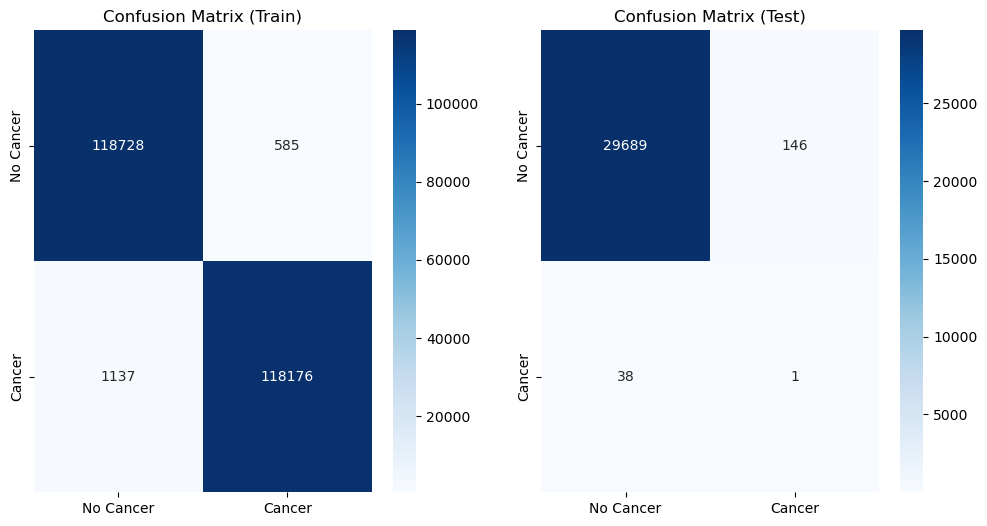

```python
# Model predictions
y_pred_train_rf = rf_model.predict(X_train)
y_pred_test_rf = rf_model.predict(X_test)

# Confusion matrix
cm_train_rf = confusion_matrix(y_train, y_pred_train_rf)
cm_test_rf = confusion_matrix(y_test, y_pred_test_rf)

# Plotting matrix
fig, ax = plt.subplots(1, 2, figsize=(12, 6))

sns.heatmap(cm_train_rf, annot=True, fmt='d', cmap='Blues', ax=ax[0],
            xticklabels=['No Cancer', 'Cancer'], yticklabels=['No Cancer', 'Cancer'])
ax[0].set_title('Confusion Matrix (Train)')

sns.heatmap(cm_test_rf, annot=True, fmt='d', cmap='Blues', ax=ax[1],
            xticklabels=['No Cancer', 'Cancer'], yticklabels=['No Cancer', 'Cancer'])
ax[1].set_title('Confusion Matrix (Test)')

plt.show()
```

```
Train scores (mean): [0.22857143 0.03928784 0.92754015 0.99516921 0.99884965]
```

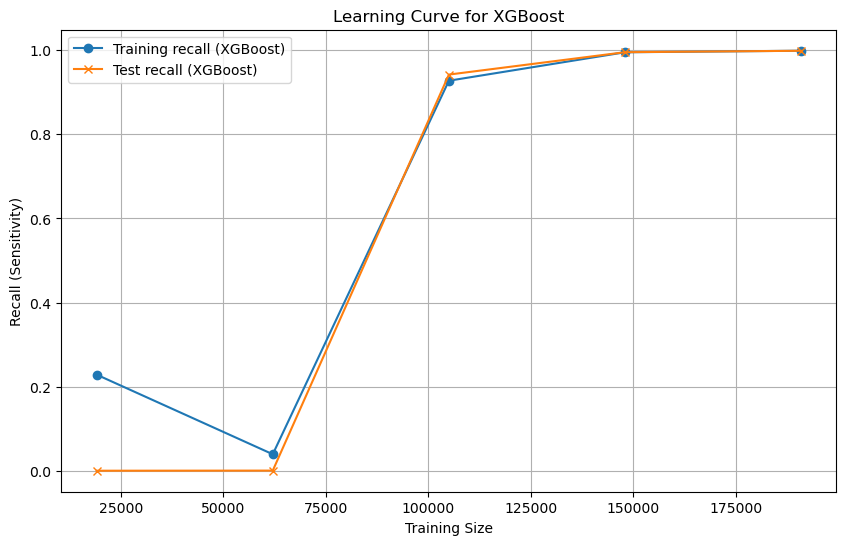

```python
# Create a custom scorer for recall with zero_division
recall_scorer = make_scorer(recall_score, zero_division=0)

# Calculate learning curves for XGBoost
train_sizes_xgb, train_scores_xgb, test_scores_xgb = learning_curve(
    xgb_model, X_train, y_train, cv=5, scoring=recall_scorer, n_jobs=-1)

# NaN or null verification
print(f"Train scores (mean): {train_scores_xgb.mean(axis=1)}")

train_mean_xgb = train_scores_xgb.mean(axis=1)
test_mean_xgb = test_scores_xgb.mean(axis=1)

# Plot
plt.figure(figsize=(10, 6))
plt.plot(train_sizes_xgb, train_mean_xgb, label='Training recall (XGBoost)', marker='o')
plt.plot(train_sizes_xgb, test_mean_xgb, label='Test recall (XGBoost)', marker='x')
plt.xlabel('Training Size')
plt.ylabel('Recall (Sensitivity)')
plt.title('Learning Curve for XGBoost')
plt.legend()
plt.grid(True)
plt.show()
```

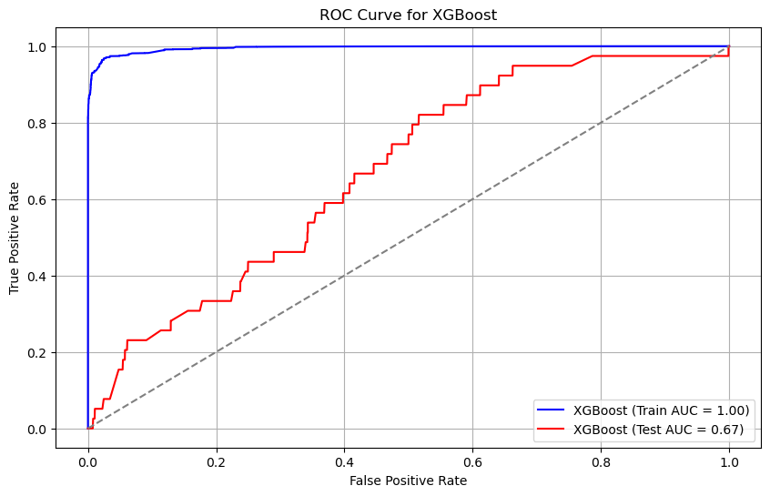

```python
# ROC for XGBoost
y_train_prob_xgb = xgb_model.predict_proba(X_train)[:, 1]
y_test_prob_xgb = xgb_model.predict_proba(X_test)[:, 1]

fpr_train_xgb, tpr_train_xgb, _ = roc_curve(y_train, y_train_prob_xgb)
fpr_test_xgb, tpr_test_xgb, _ = roc_curve(y_test, y_test_prob_xgb)

roc_auc_train_xgb = auc(fpr_train_xgb, tpr_train_xgb)
roc_auc_test_xgb = auc(fpr_test_xgb, tpr_test_xgb)

# ROC plot
plt.figure(figsize=(10, 6))
plt.plot(fpr_train_xgb, tpr_train_xgb, color='blue', label=f'XGBoost (Train AUC = {roc_auc_train_xgb:.2f})')
plt.plot(fpr_test_xgb, tpr_test_xgb, color='red', label=f'XGBoost (Test AUC = {roc_auc_test_xgb:.2f})')
plt.plot([0, 1], [0, 1], color='gray', linestyle='--')
plt.xlabel('False Positive Rate')
plt.ylabel('True Positive Rate')
plt.title('ROC Curve for XGBoost')
plt.legend(loc='lower right')
plt.grid()
plt.show()
```

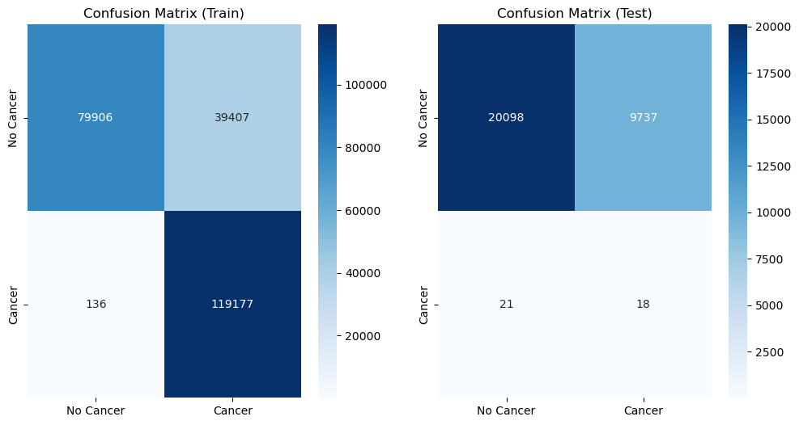

```python
# Confussion Matrix for XGBoost
y_pred_train_xgb = xgb_model.predict(X_train)
y_pred_test_xgb = xgb_model.predict(X_test)

cm_train_xgb = confusion_matrix(y_train, y_pred_train_xgb)
cm_test_xgb = confusion_matrix(y_test, y_pred_test_xgb)

fig, ax = plt.subplots(1, 2, figsize=(12, 6))

sns.heatmap(cm_train_xgb, annot=True, fmt='d', cmap='Blues', ax=ax[0],
            xticklabels=['No Cancer', 'Cancer'], yticklabels=['No Cancer', 'Cancer'])
ax[0].set_title('Confusion Matrix (Train)')

sns.heatmap(cm_test_xgb, annot=True, fmt='d', cmap='Blues', ax=ax[1],
            xticklabels=['No Cancer', 'Cancer'], yticklabels=['No Cancer', 'Cancer'])
ax[1].set_title('Confusion Matrix (Test)')

plt.show()
```

# Model selection

After evaluating the models using multiple performance metrics, the next step is to select the best model for liver cancer prediction. The selection process is based on a combination of factors, including:

- **Performance Metrics:** Accuracy, recall, precision, F1-score, and ROC-AUC scores.
- **Generalization Ability:** How well the model performs on unseen data, avoiding overfitting.
- **Feature Importance:** Evaluating which features contribute most to the model’s predictions.
- **Computational Efficiency:** Considering training time and complexity, especially for real-world applications.

```python
importances = rf_randomized_search.best_estimator_.feature_importances_
importances
```

```
array([0.05714622, 0.04329807, 0.1156936 , 0.02817861, 0.05604537,
       0.03291485, 0.1923904 , 0.03740601, 0.19825113, 0.01254496,
       0.12041694, 0.05814102, 0.0475728 ])
```

```python
# Getting feature importances
importances = rf_randomized_search.best_estimator_.feature_importances_

# Getting the names
feature_names = X_train.columns

# DataFrame creation to order the variables
feature_importance_df = pd.DataFrame({
    'feature': feature_names,
    'importance': importances
})

feature_importance_df = feature_importance_df.sort_values(by='importance', ascending=False)

# Showing results
print(feature_importance_df)
```

```
           feature  importance
8   bmi_curc_raiz4    0.198251
6    bmi_50c_raiz4    0.192390
10    agelevel_log    0.120417
2    bmi_20c_raiz4    0.115694
11     fmenstr_log    0.058141
0        race7_log    0.057146
4   smokea_f_raiz4    0.056045
12     menstrs_log    0.047573
1   filtered_f_log    0.043298
7   ssmokea_f_sqrt    0.037406
5     cig_stat_exp    0.032915
3          arm_sqr    0.028179
9       preg_f_log    0.012545
```

# SHAP CONFIGURATION

Understanding how machine learning models make predictions is crucial, especially in high-stakes applications like healthcare and finance. SHAP (SHapley Additive exPlanations) is a powerful framework based on game theory that helps explain the contribution of each feature to a model’s predictions. It provides global and local interpretability, making it an essential tool for model transparency and trustworthiness.

In this section, we explore three key SHAP visualization techniques:

- **Summary Plot:** Provides a global overview of feature importance and their impact on predictions.
- **Decision Plot:** Visualizes how features contribute to individual predictions in a stepwise manner.
- **Force Plot:** Shows local interpretability by illustrating the push-and-pull effect of features on specific predictions.

By leveraging SHAP, we gain valuable insights into model behavior, identify biases, and enhance decision-making in machine learning applications.

```python
# Model to explain selection (RandomForest or XGBoost)
model_to_explain_xgb = xgb_model

# TreeExplained SHAP creation
explainer_xgb = shap.TreeExplainer(model_to_explain_xgb)
shap_values_xgb = explainer_xgb.shap_values(X_test)
```

# Summary plot

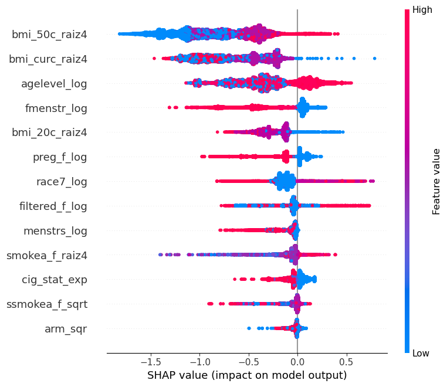

```python
shap.summary_plot(shap_values_xgb, X_test, feature_names=X_test.columns)
```

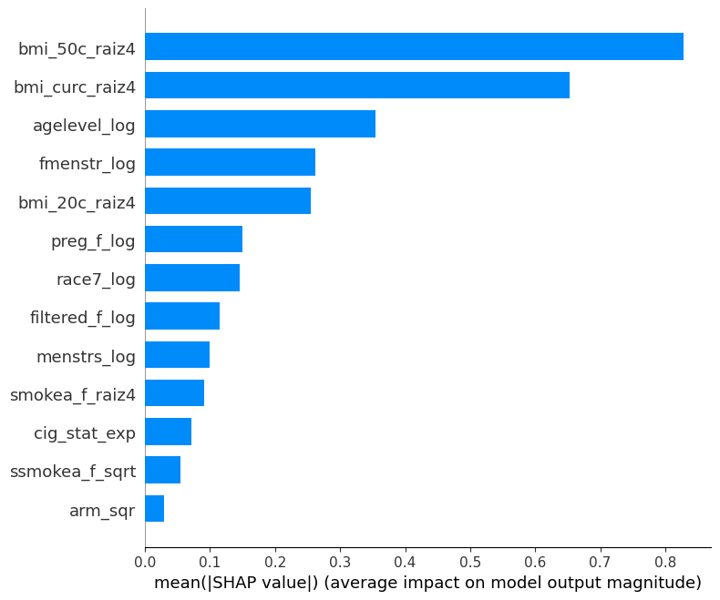

```python
plt.figure(figsize=(12, 10))
shap.summary_plot(shap_values_xgb, X_test, feature_names=X_test.columns, plot_type='bar')
```

# Decision plot

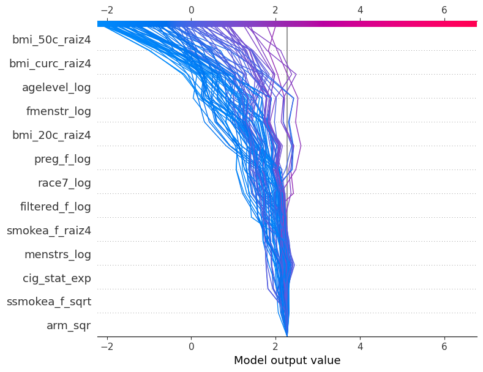

```python
# Filter only a subset
num_samples = 100
X_test_sample = X_test.iloc[:num_samples]

expected_value = explainer_xgb.expected_value

if isinstance(expected_value, list):
    expected_value = expected_value[0]

if isinstance(shap_values_xgb, list):
    shap_values_xgb = shap_values_xgb[0]


feature_names = list(X_test.columns)

shap.decision_plot(expected_value, shap_values_xgb[:num_samples], X_test_sample, feature_names=feature_names)
```

This analysis using **SHAP decision plots** provides valuable insights into how **individual features contribute to model predictions**, improving the **interpretability of the XGBoost model** in liver cancer detection. By visualizing the impact of each factor, we can better understand the decision-making process and enhance trust in the model’s predictions.

# Force plot

```python
shap.initjs()
shap.force_plot(explainer_xgb.expected_value, shap_values_xgb[:50], X_test.iloc[:50,:])
```

[output not shown]

The **SHAP Force Plot** is an interactive visualization that shows how each feature influences the prediction for a specific patient.

It is an excellent tool for intuitively explaining **individual model decisions** and understanding how different variables contribute to a prediction.

## **How to Interpret the Force Plot?**

### **Features Affecting the Prediction**

The patient's features are displayed as **blocks pushing the prediction up or down**.

- **Red 🔴 → Increases the prediction** (indicates a higher risk of cancer).
- **Blue 🔵 → Decreases the prediction** (indicates a lower risk of cancer).

### **Negative Impact (Decreases the Prediction)**

Features such as **`bmi_50c_raiz4`** or **`agelevel_log`** may lower the prediction **if the patient's values indicate a reduced risk**.  
If a patient has **lower BMI** or **is younger**, their estimated risk will be **lower**.